> **Tip**: Welcome to the Investigate a Dataset project! You will find tips in quoted sections like this to help organize your approach to your investigation. Once you complete this project, remove these **Tip** sections from your report before submission. First things first, you might want to double-click this Markdown cell and change the title so that it reflects your dataset and investigation.

# Project: Investigate a Dataset - [No-show appointments]

- Introduction
- Data Wrangling
- Exploratory Data Analysis
- Conclusions

## Introduction

This project is a practical application of statistical operations and visualization on a Dataset, I will analyze the Medical Appointment using numpy,pandas, matplotlib, and seaborn pakages

### Dataset Description

This dataset collects information from 100k medical appointments in Brazil and is focused on the question of whether or not patients show up for their appointment. A number of characteristics about the patient are included in each row.

- ‘ScheduledDay’ tells us on what day the patient set up their appointment.
- ‘Neighborhood’ indicates the location of the hospital.
- ‘Scholarship’ indicates whether or not the patient is enrolled in Brasilian welfare program Bolsa Família.
- 'noshow' indicates whether or not the patient showed up their appointment
- Be careful about the encoding of the last column: it says ‘No’ if the patient showed up to their appointment, and ‘Yes’ if they did not show up.
- The number under the following columns label (Scholarship, Hypertension, Alcoholism, Diabetes): True = 1 and False = 0

```python
#  importing statements for all of the packages that I
#   plan to use.

import numpy as np
import pandas as pd
import matplotlib.pyplot as plt
import seaborn as sns
%matplotlib inline
```

```python
# Upgrade pandas to use dataframe.explode() function.
# !pip install --upgrade pandas==0.25.0
```

## Data Wrangling

> **Tip**: In this section of the report, I will load in the data, check for cleanliness, and then trim and clean my dataset for analysis.

## 1. Gathering Data

```python
# Load your data and print out a few lines. Perform operations to inspect data
#   types and look for instances of missing or possibly errant data.

df = pd.read_csv('KaggleV2-May-2016.csv')
df.head(2)
```

|  | PatientId | AppointmentID | Gender | ScheduledDay | AppointmentDay | Age | Neighbourhood | Scholarship | Hipertension | Diabetes | Alcoholism | Handcap | SMS_received | No-show |
| --- | --- | --- | --- | --- | --- | --- | --- | --- | --- | --- | --- | --- | --- | --- |
| 0 | 2.987250e+13 | 5642903 | F | 2016-04-29T18:38:08Z | 2016-04-29T00:00:00Z | 62 | JARDIM DA PENHA | 0 | 1 | 0 | 0 | 0 | 0 | No |
| 1 | 5.589978e+14 | 5642503 | M | 2016-04-29T16:08:27Z | 2016-04-29T00:00:00Z | 56 | JARDIM DA PENHA | 0 | 0 | 0 | 0 | 0 | 0 | No |

## 2. Assessing Data

```python
# exploring data info.
df.info()
```

```
<class 'pandas.core.frame.DataFrame'>
RangeIndex: 110527 entries, 0 to 110526
Data columns (total 14 columns):
 #   Column          Non-Null Count   Dtype
---  ------          --------------   -----
 0   PatientId       110527 non-null  float64
 1   AppointmentID   110527 non-null  int64
 2   Gender          110527 non-null  object
 3   ScheduledDay    110527 non-null  object
 4   AppointmentDay  110527 non-null  object
 5   Age             110527 non-null  int64
 6   Neighbourhood   110527 non-null  object
 7   Scholarship     110527 non-null  int64
 8   Hipertension    110527 non-null  int64
 9   Diabetes        110527 non-null  int64
 10  Alcoholism      110527 non-null  int64
 11  Handcap         110527 non-null  int64
 12  SMS_received    110527 non-null  int64
 13  No-show         110527 non-null  object
dtypes: float64(1), int64(8), object(5)
memory usage: 11.8+ MB
```

### ## - by looking for the above data we can see that (ScheduledDay and AppointmentDay) has to be datetime instead of object , we will fix it at the clean section

```python
# check for missing values
df.isnull().sum()
```

```
PatientId         0
AppointmentID     0
Gender            0
ScheduledDay      0
AppointmentDay    0
Age               0
Neighbourhood     0
Scholarship       0
Hipertension      0
Diabetes          0
Alcoholism        0
Handcap           0
SMS_received      0
No-show           0
dtype: int64
```

- No missing values found

```python
# exploring duplicates
df.duplicated().sum()
```

```
0
```

```python
# inspecting data
df.describe()
```

|  | PatientId | AppointmentID | Age | Scholarship | Hipertension | Diabetes | Alcoholism | Handcap | SMS_received |
| --- | --- | --- | --- | --- | --- | --- | --- | --- | --- |
| count | 1.105270e+05 | 1.105270e+05 | 110527.000000 | 110527.000000 | 110527.000000 | 110527.000000 | 110527.000000 | 110527.000000 | 110527.000000 |
| mean | 1.474963e+14 | 5.675305e+06 | 37.088874 | 0.098266 | 0.197246 | 0.071865 | 0.030400 | 0.022248 | 0.321026 |
| std | 2.560949e+14 | 7.129575e+04 | 23.110205 | 0.297675 | 0.397921 | 0.258265 | 0.171686 | 0.161543 | 0.466873 |
| min | 3.921784e+04 | 5.030230e+06 | -1.000000 | 0.000000 | 0.000000 | 0.000000 | 0.000000 | 0.000000 | 0.000000 |
| 25% | 4.172614e+12 | 5.640286e+06 | 18.000000 | 0.000000 | 0.000000 | 0.000000 | 0.000000 | 0.000000 | 0.000000 |
| 50% | 3.173184e+13 | 5.680573e+06 | 37.000000 | 0.000000 | 0.000000 | 0.000000 | 0.000000 | 0.000000 | 0.000000 |
| 75% | 9.439172e+13 | 5.725524e+06 | 55.000000 | 0.000000 | 0.000000 | 0.000000 | 0.000000 | 0.000000 | 1.000000 |
| max | 9.999816e+14 | 5.790484e+06 | 115.000000 | 1.000000 | 1.000000 | 1.000000 | 1.000000 | 4.000000 | 1.000000 |

```python
# query for the unbelievable age which I will remove it
outlier_age = df.query('Age<0 | Age>100')
outlier_age
```

|  | PatientId | AppointmentID | Gender | ScheduledDay | AppointmentDay | Age | Neighbourhood | Scholarship | Hipertension | Diabetes | Alcoholism | Handcap | SMS_received | No-show |
| --- | --- | --- | --- | --- | --- | --- | --- | --- | --- | --- | --- | --- | --- | --- |
| 58014 | 9.762948e+14 | 5651757 | F | 2016-05-03T09:14:53Z | 2016-05-03T00:00:00Z | 102 | CONQUISTA | 0 | 0 | 0 | 0 | 0 | 0 | No |
| 63912 | 3.196321e+13 | 5700278 | F | 2016-05-16T09:17:44Z | 2016-05-19T00:00:00Z | 115 | ANDORINHAS | 0 | 0 | 0 | 0 | 1 | 0 | Yes |
| 63915 | 3.196321e+13 | 5700279 | F | 2016-05-16T09:17:44Z | 2016-05-19T00:00:00Z | 115 | ANDORINHAS | 0 | 0 | 0 | 0 | 1 | 0 | Yes |
| 68127 | 3.196321e+13 | 5562812 | F | 2016-04-08T14:29:17Z | 2016-05-16T00:00:00Z | 115 | ANDORINHAS | 0 | 0 | 0 | 0 | 1 | 0 | Yes |
| 76284 | 3.196321e+13 | 5744037 | F | 2016-05-30T09:44:51Z | 2016-05-30T00:00:00Z | 115 | ANDORINHAS | 0 | 0 | 0 | 0 | 1 | 0 | No |
| 90372 | 2.342836e+11 | 5751563 | F | 2016-05-31T10:19:49Z | 2016-06-02T00:00:00Z | 102 | MARIA ORTIZ | 0 | 0 | 0 | 0 | 0 | 0 | No |
| 97666 | 7.482346e+14 | 5717451 | F | 2016-05-19T07:57:56Z | 2016-06-03T00:00:00Z | 115 | SÃO JOSÉ | 0 | 1 | 0 | 0 | 0 | 1 | No |
| 99832 | 4.659432e+14 | 5775010 | F | 2016-06-06T08:58:13Z | 2016-06-06T00:00:00Z | -1 | ROMÃO | 0 | 0 | 0 | 0 | 0 | 0 | No |

## 3. Data Cleaning

> **Tip**: change data type for (ScheduledDay and AppointmentDay) to be datetime64

```python
columns = ['ScheduledDay', 'AppointmentDay']
for column in columns:
    df[column] = pd.to_datetime(pd.to_datetime(df[column]).dt.date)

print(df.dtypes)
df.head(2)
```

```
PatientId                float64
AppointmentID              int64
Gender                    object
ScheduledDay      datetime64[ns]
AppointmentDay    datetime64[ns]
Age                        int64
Neighbourhood             object
Scholarship                int64
Hipertension               int64
Diabetes                   int64
Alcoholism                 int64
Handcap                    int64
SMS_received               int64
No-show                   object
dtype: object
```

|  | PatientId | AppointmentID | Gender | ScheduledDay | AppointmentDay | Age | Neighbourhood | Scholarship | Hipertension | Diabetes | Alcoholism | Handcap | SMS_received | No-show |
| --- | --- | --- | --- | --- | --- | --- | --- | --- | --- | --- | --- | --- | --- | --- |
| 0 | 2.987250e+13 | 5642903 | F | 2016-04-29 | 2016-04-29 | 62 | JARDIM DA PENHA | 0 | 1 | 0 | 0 | 0 | 0 | No |
| 1 | 5.589978e+14 | 5642503 | M | 2016-04-29 | 2016-04-29 | 56 | JARDIM DA PENHA | 0 | 0 | 0 | 0 | 0 | 0 | No |

> **Tip**: I am going to remove the unbelievable age which i discover in the last section.

```python
# removing the unbelievable age and saving the changes
df.drop(df[(df.Age<0) | (df.Age>100)].index, inplace=True)
```

```python
df.describe()
```

|  | PatientId | AppointmentID | Age | Scholarship | Hipertension | Diabetes | Alcoholism | Handcap | SMS_received |
| --- | --- | --- | --- | --- | --- | --- | --- | --- | --- |
| count | 1.105190e+05 | 1.105190e+05 | 110519.000000 | 110519.000000 | 110519.000000 | 110519.000000 | 110519.000000 | 110519.000000 | 110519.000000 |
| mean | 1.474860e+14 | 5.675303e+06 | 37.084519 | 0.098273 | 0.197251 | 0.071870 | 0.030402 | 0.022213 | 0.321040 |
| std | 2.560826e+14 | 7.129600e+04 | 23.103165 | 0.297684 | 0.397925 | 0.258274 | 0.171692 | 0.161441 | 0.466878 |
| min | 3.921784e+04 | 5.030230e+06 | 0.000000 | 0.000000 | 0.000000 | 0.000000 | 0.000000 | 0.000000 | 0.000000 |
| 25% | 4.172457e+12 | 5.640284e+06 | 18.000000 | 0.000000 | 0.000000 | 0.000000 | 0.000000 | 0.000000 | 0.000000 |
| 50% | 3.172598e+13 | 5.680569e+06 | 37.000000 | 0.000000 | 0.000000 | 0.000000 | 0.000000 | 0.000000 | 0.000000 |
| 75% | 9.438963e+13 | 5.725522e+06 | 55.000000 | 0.000000 | 0.000000 | 0.000000 | 0.000000 | 0.000000 | 1.000000 |
| max | 9.999816e+14 | 5.790484e+06 | 100.000000 | 1.000000 | 1.000000 | 1.000000 | 1.000000 | 4.000000 | 1.000000 |

- the rows were removed successfuly

### Now I am going to clean Data by deleting unnecessary Columns

```python
# deleting unnecessary columns
df.drop(columns=['PatientId', 'AppointmentID'], inplace=True)
```

```python
df.head(1)
```

|  | Gender | ScheduledDay | AppointmentDay | Age | Neighbourhood | Scholarship | Hipertension | Diabetes | Alcoholism | Handcap | SMS_received | No-show |
| --- | --- | --- | --- | --- | --- | --- | --- | --- | --- | --- | --- | --- |
| 0 | F | 2016-04-29 | 2016-04-29 | 62 | JARDIM DA PENHA | 0 | 1 | 0 | 0 | 0 | 0 | No |

- the two columns were removed successfuly

```python
# rename 'No-show' column to simplify manpulating with it
df.rename(columns={'No-show' : 'noshow'}, inplace=True)
df.head(1)
```

|  | Gender | ScheduledDay | AppointmentDay | Age | Neighbourhood | Scholarship | Hipertension | Diabetes | Alcoholism | Handcap | SMS_received | noshow |
| --- | --- | --- | --- | --- | --- | --- | --- | --- | --- | --- | --- | --- |
| 0 | F | 2016-04-29 | 2016-04-29 | 62 | JARDIM DA PENHA | 0 | 1 | 0 | 0 | 0 | 0 | No |

```python
# rename wrong 'Hipertension' column name to be 'Hypertension'
df.rename(columns={'Hipertension' : 'Hypertension'}, inplace=True)
df.head(1)
```

|  | Gender | ScheduledDay | AppointmentDay | Age | Neighbourhood | Scholarship | Hypertension | Diabetes | Alcoholism | Handcap | SMS_received | noshow |
| --- | --- | --- | --- | --- | --- | --- | --- | --- | --- | --- | --- | --- |
| 0 | F | 2016-04-29 | 2016-04-29 | 62 | JARDIM DA PENHA | 0 | 1 | 0 | 0 | 0 | 0 | No |

## Exploratory Data Analysis

### General visualization for dataset

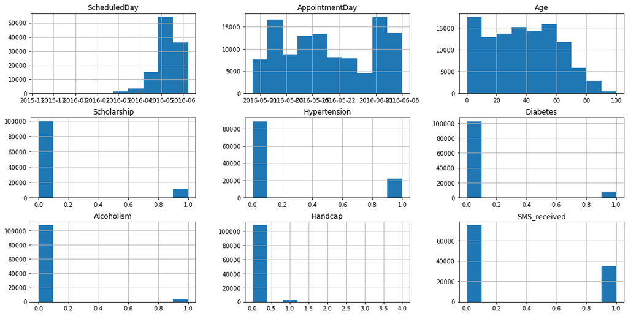

```python
df.hist(figsize=(18, 9));
```

```python
# compare between show and no-show
df[df.noshow=='No'].count(), df[df.noshow=='Yes'].count()
```

```
(Gender            88203
 ScheduledDay      88203
 AppointmentDay    88203
 Age               88203
 Neighbourhood     88203
 Scholarship       88203
 Hypertension      88203
 Diabetes          88203
 Alcoholism        88203
 Handcap           88203
 SMS_received      88203
 noshow            88203
 dtype: int64,
 Gender            22316
 ScheduledDay      22316
 AppointmentDay    22316
 Age               22316
 Neighbourhood     22316
 Scholarship       22316
 Hypertension      22316
 Diabetes          22316
 Alcoholism        22316
 Handcap           22316
 SMS_received      22316
 noshow            22316
 dtype: int64)
```

### declaring how many show , no-show, and the average for both

```python
# the patient amount
df.noshow.count()
```

```
110519
```

```python
# total showed up  patients
p =(df.noshow=='No').sum()
p
```

```
88203
```

```python
# total non-showed patients
a =(df.noshow=='Yes').sum()
a
```

```
22316
```

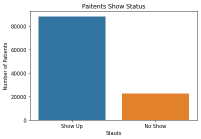

```python
# bar chart for noshow column

sns.countplot(data = df, x = 'noshow')
plt.title('Paitents Show Status')
plt.xticks([0, 1], ['Show Up', 'No Show'])
plt.xlabel('Stauts')
plt.ylabel('Number of Patients');
```

```python
# average for showed patients
p_average = (p/(p+a))*100
p_average
```

```
79.80799681502728
```

```python
# average for no-show patients
a_average = (a/(p+a))*100
a_average
```

```
20.19200318497272
```

```python
# detailed mean for show and no-show
df[df.noshow=='No'].mean(), df[df.noshow=='Yes'].mean()
```

```
(Age             37.787297
 Scholarship      0.093908
 Hypertension     0.204392
 Diabetes         0.073841
 Alcoholism       0.030418
 Handcap          0.022732
 SMS_received     0.291339
 dtype: float64,
 Age             34.306820
 Scholarship      0.115522
 Hypertension     0.169027
 Diabetes         0.064080
 Alcoholism       0.030337
 Handcap          0.020165
 SMS_received     0.438430
 dtype: float64)
```

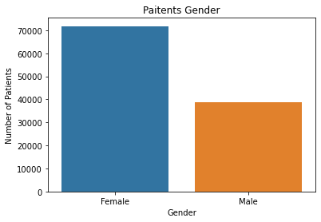

```python
# bar chart for gender
sns.countplot(data = df, x = 'Gender')
plt.title('Paitents Gender')
plt.xticks([0, 1], ['Female', 'Male'])
plt.xlabel('Gender')
plt.ylabel('Number of Patients');
```

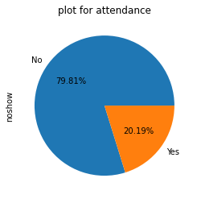

```python
# pie plot for show and no-show percentage
df['noshow'].value_counts().plot(kind='pie', title= 'plot for attendance', autopct='%.2f%%');
```

- as we see that (79.81%) showed up their appointment

### Research Question 1 (How does showed up affected by Gender factor? )

```python
def pie_plot(col_name):
    df.groupby([col_name, 'noshow']).count()['Age'].plot(kind='pie', title= 'percentage by {} attendance'.format(col_name), autopct='%.2f%%')
    plt.xlabel(col_name)
    plt.ylabel('')
```

```python
def bar_plot(col_name):
    df.groupby([col_name, 'noshow']).count()['Age'].plot(kind='bar', title= 'percentage by {} attendance'.format(col_name))
    plt.xlabel(col_name)
    plt.ylabel('patients count')
```

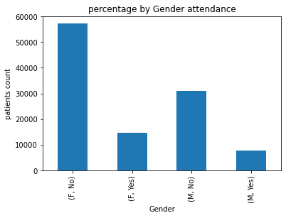

```python
# Bar plot for 'Gender' factor
bar_plot('Gender')
```

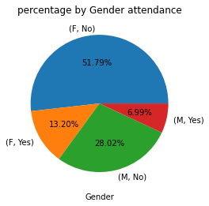

```python
# Pie plot for 'Gender' factor

pie_plot('Gender')
```

- as shown above the (Gender) is Not an influential factor to predict that Pacients will showed up their appointment

### Research Question 2 (How does showed up affected by( Handcap, Hypertension, Diabetes, Alcoholism, factors?

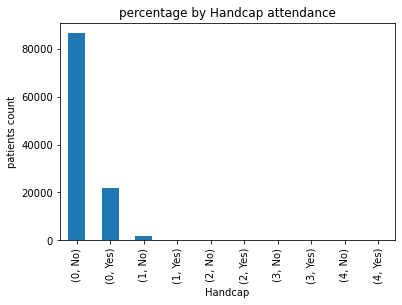

```python
# Bar plot for 'Handcap' factor
bar_plot('Handcap')
```

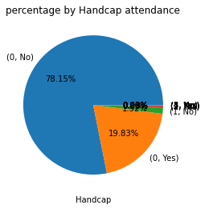

```python
# Pie plot for 'Handcap' factor
pie_plot('Handcap')
```

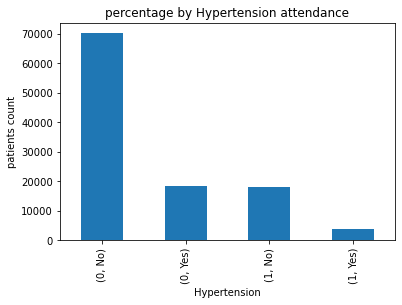

```python
# Bar plot for 'Hypertension' factor
bar_plot('Hypertension')
```

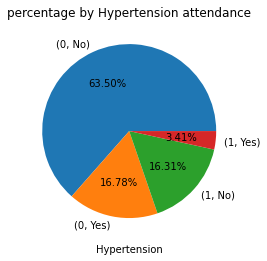

```python
# Pie plot for 'Hypertension' factor
pie_plot('Hypertension')
```

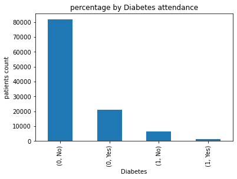

```python
# Bar plot for 'Diabetes' factor
bar_plot('Diabetes')
```

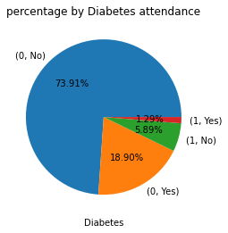

```python
# Pie plot for 'Diabetes' factor
pie_plot('Diabetes')
```

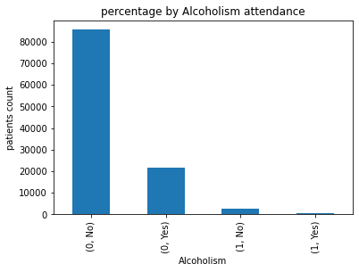

```python
# Bar plot for 'Alcoholism' factor
bar_plot('Alcoholism')
```

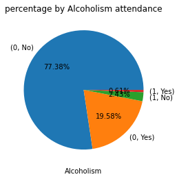

```python
# Pie plot for 'Alcoholism' factor
pie_plot('Alcoholism')
```

### Research Question 3 ( is 'Scholarship' factor can predict if the partients will attend their appointment ?)

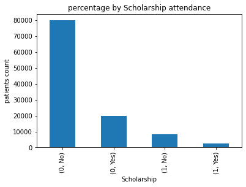

```python
# Bar plot for 'Scolarship' factor
bar_plot('Scholarship')
```

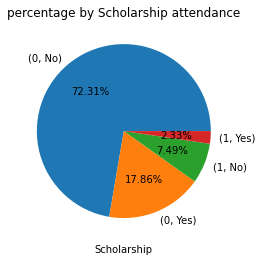

```python
# Pie plot for 'Scholarship' factor
pie_plot('Scholarship')
```

- the Scholarship factor cannot predict if the partients will attend their appointment

### Research Question 4 ( What is the influential of 'SMS_received' on showed up the appointment ?)

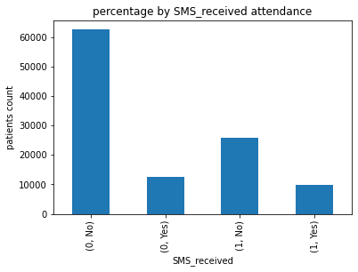

```python
# Bar plot for 'SMS_received' factor
bar_plot('SMS_received')
```

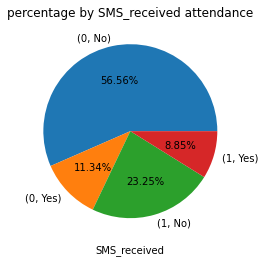

```python
# Pie plot for 'SMS_received' factor
pie_plot('SMS_received')
```

- 'SMS received' has an adverse effect on attendance

### Research Question 5: How is age affecting the patient's absence?

```python
present = df.noshow=='No'
absent = df.noshow=='Yes'
```

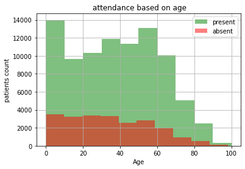

```python
def attend(df, column_n, showed, non_showed):
    df[column_n][present].hist(alpha=.5, bins=10, color='green', label = 'present')
    df[column_n][absent].hist(alpha=.5, bins=10, color='red', label = 'absent')
    plt.legend()
    plt.title(' attendance based on age')
    plt.xlabel('Age')
    plt.ylabel('patients count')
attend(df, 'Age', present, absent)
```

- we can see that the most attendance if for Kids which their ages from 0 to 8 years

## Conclusions

> **Tip**: After analyzed the no-show data for the medical appointment I've got findings and i can recap it as follows :
> 1. the data set contained 110.527 appointments and 20.19% not showed
> 2. most of patient were females and didn't have a scholarship , and they were young
> 3. the SMS received' has an adverse effect on attendance so we have to revisit it.

### Limitations

> **Tip**: it would be better if we have updated dataset , since the data is too earlier

```python
from subprocess import call
call(['python', '-m', 'nbconvert', 'Investigate_a_Dataset.ipynb'])
```

[output not shown]

```
1
```